# EconML with R in the Tidyverse

Example Usage with Multiple Continuous Treatment, Multiple Outcome Observational Data

Itamar Caspi

2019-11-04

Abstract

[`EconML`](https://github.com/microsoft/EconML) is a Python package for estimating heterogeneous treatment effects from observational data via machine learning. In this note you I show how to call EconML from R using the [`reticulate`](https://rstudio.github.io/reticulate/index.html) package. To this end, I reproduce an example for usage with multiple continuous treatment and multiple outcomes observational data that appear in the [“Double Machine Learning: Use Cases and Examples”](https://github.com/microsoft/EconML/blob/master/notebooks/Double%20Machine%20Learning%20Examples.ipynb) EconML notebook. The code adheres as closely as possible to the [Tidyverse](https://www.tidyverse.org) [principles](https://principles.tidyverse.org) and [style](https://style.tidyverse.org).

**NOTE** In order to run this tutorial, make sure you’ve pre-installed a Python environment, as well as the [`econml`](https://github.com/microsoft/EconML#installation) and [`sklearn`](https://scikit-learn.org/stable/install.html) Python packages.

## Introduction

An excerpt from [“Double Machine Learning: Use Cases and Examples”](https://github.com/microsoft/EconML/blob/master/notebooks/Double%20Machine%20Learning%20Examples.ipynb) EconML notebook:

> *“We use the same data, but in this case, we want to fit the demand of multiple brand as a function of the price of each one of them, i.e. fit the matrix of cross price elasticities. It can be done, by simply setting as $Y$ to be the vector of demands and $T$ to be the vector of prices. Then we can obtain the matrix of cross price elasticities.”*

(See [previous note](https://raw.githack.com/itamarcaspi/EconML-with-R/master/single.html) for context.)

## Packages

Load `reticulate and set up a virtual Python environment

```r
library(reticulate)
use_virtualenv("myenv")
```

Load other required packages

```r
library(tidyverse) # for data wrangling and visualization
library(recipes)   # for data preprocessing
library(here)      # for file referencing
library(glue)      # for pasting strings
```

## Data

Load the orange juice dataset

```r
# Read from file
oj_raw <- read_csv(here("data", "oj_large.csv"))

# Alternatively, read from the web
# oj_raw <- read_csv("https://msalicedatapublic.blob.core.windows.net/datasets/OrangeJuice/oj_large.csv")

head(oj_raw)
```

```
## # A tibble: 6 x 17
##   store brand  week logmove  feat price AGE60  EDUC ETHNIC INCOME HHLARGE
##   <dbl> <chr> <dbl>   <dbl> <dbl> <dbl> <dbl> <dbl>  <dbl>  <dbl>   <dbl>
## 1     2 trop~    40    9.02     0  3.87 0.233 0.249  0.114   10.6   0.104
## 2     2 trop~    46    8.72     0  3.87 0.233 0.249  0.114   10.6   0.104
## 3     2 trop~    47    8.25     0  3.87 0.233 0.249  0.114   10.6   0.104
## 4     2 trop~    48    8.99     0  3.87 0.233 0.249  0.114   10.6   0.104
## 5     2 trop~    50    9.09     0  3.87 0.233 0.249  0.114   10.6   0.104
## 6     2 trop~    51    8.88     0  3.87 0.233 0.249  0.114   10.6   0.104
## # ... with 6 more variables: WORKWOM <dbl>, HVAL150 <dbl>, SSTRDIST <dbl>,
## #   SSTRVOL <dbl>, CPDIST5 <dbl>, CPWVOL5 <dbl>
```

## Preprocessing

```r
stores <- oj_raw %>%
  select(store, AGE60:CPWVOL5) %>%
  group_by(store) %>%
  summarise_all(.funs = ~ mean(.))

oj <- oj_raw %>%
  select(store, week, brand, logmove, price) %>%
  pivot_wider(names_from = brand, values_from = c(logmove, price)) %>%
  left_join(stores)

head(oj)
```

```
## # A tibble: 6 x 19
##   store  week logmove_tropica~ logmove_minute.~ logmove_dominic~
##   <dbl> <dbl>            <dbl>            <dbl>            <dbl>
## 1     2    40             9.02             8.41             9.26
## 2     2    46             8.72             8.45             8.99
## 3     2    47             8.25             9.91             8.83
## 4     2    48             8.99             7.90             7.97
## 5     2    50             9.09             8.01             7.38
## 6     2    51             8.88             8.45            10.1
## # ... with 14 more variables: price_tropicana <dbl>,
## #   price_minute.maid <dbl>, price_dominicks <dbl>, AGE60 <dbl>,
## #   EDUC <dbl>, ETHNIC <dbl>, INCOME <dbl>, HHLARGE <dbl>, WORKWOM <dbl>,
## #   HVAL150 <dbl>, SSTRDIST <dbl>, SSTRVOL <dbl>, CPDIST5 <dbl>,
## #   CPWVOL5 <dbl>
```

```r
oj_rec <- recipe( ~ ., data = oj) %>%
  step_normalize(
    INCOME, AGE60, EDUC, ETHNIC, INCOME,
    HHLARGE, WORKWOM, HVAL150, SSTRDIST,
    SSTRVOL, CPDIST5, CPWVOL5
  ) %>%
  step_log(starts_with("price")) %>%
  prep() %>%
  juice()
```

```r
Y <- oj_rec %>%
  select(starts_with("logmove")) %>%
  as.matrix() %>%
  unname()

D <- oj_rec %>%
  select(starts_with("price")) %>%
  as.matrix() %>%
  unname()

X <- oj_rec %>%
  select(INCOME) %>%
  as.matrix() %>%
  unname()

W <- oj_rec %>%
  select(AGE60:CPWVOL5, -INCOME) %>%
  as.matrix() %>%
  unname()
```

Generate test data

```r
min_income <- -1
max_income <- 1
delta      <- (max_income - min_income) / 100

X_test <- seq(max_income, min_income, -delta) %>%
  as.matrix()
```

## Estimate CATE

Here is where the magic happens. The following two code chunks are written in Python. The first code chunk imports the necessary libraries - `econml` for estimating HTE and `sklearn`, a ML modeling and preprocessing tool.

```python
from econml.dml import DMLCateEstimator
from sklearn.linear_model import MultiTaskElasticNetCV
```

This is where the estimation takes place. Note that referring to R objects while in Python is done using the `r.` prefix. For example, `r.Y` returns R’s `Y` object in Python.

```python
est = DMLCateEstimator(model_y=MultiTaskElasticNetCV(cv=3),model_t=MultiTaskElasticNetCV(cv=3))

est.fit(r.Y, r.D, r.X, r.W)

te_pred = est.const_marginal_effect(r.X_test)
```

And now, back to R. Note that referring to python objects while in R is done using the `py$` prefix. For example, `py$te_pred` returns python’s `te_pred` object in R.

Tidy `econml`’s output

```r
brands <- oj_raw %>%
  distinct(brand) %>%
  pull()

cate_effect <- tibble("Xtest" = X_test)

for (i in 1:length(brands)) {
  for (j in 1:length(brands)) {
    elas_val = tibble(py$te_pred[ , i, j])
    names(elas_val) <- glue("{brands[i]}_{brands[j]}_mid")
    cate_effect <- bind_cols(cate_effect, elas_val)
  }
}

cate_effect_long <- cate_effect %>%
  pivot_longer(
    -Xtest,
    names_to  = c("cross_product", "product", "estimate"),
    names_sep = "_",
    values_to = "value"
  )
```

Plot orange Juice elasticity as a function of income

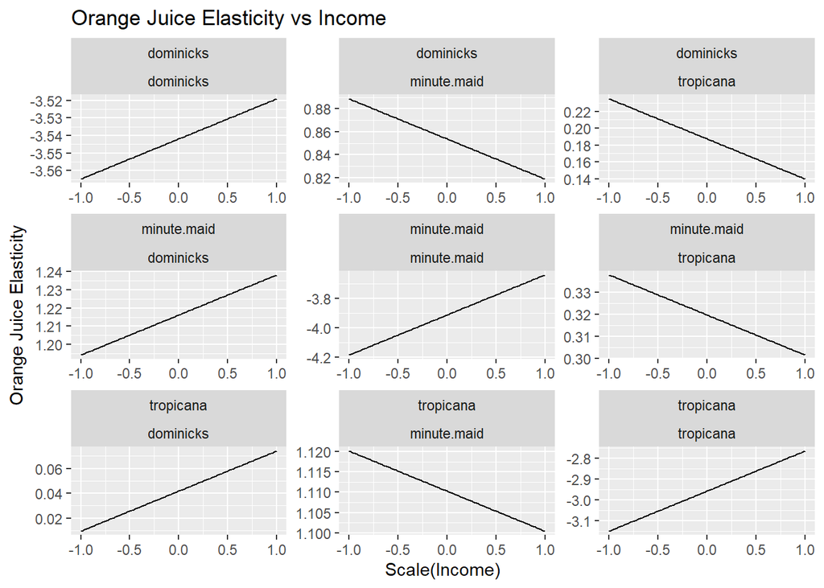

```r
cate_effect_long %>%
  ggplot(aes(Xtest, value)) +
  geom_line() +
  facet_wrap( ~ product + cross_product, scales = "free") +
  labs(
    x = "Scale(Income)",
    y = "Orange Juice Elasticity",
    title = "Orange Juice Elasticity vs Income"
  )
```

> *“Look at the diagonal of the matrix, the TE of OJ prices are always negative to the sales across all the brand, but people with higher income are less price-sensitive. By contrast, for the non-diagonal of the matrix, the TE of prices for other brands are always positive to the sales for that brand, the TE is affected by income in different ways for different competitors. In addition, compare to previous plot, the negative TE of OJ prices for each brand are all larger than the TE considering all brand together, which means we would have underestimated the effect of price changes on demand.”*

## Bootstrap Confidence Intervals

```python
from econml.bootstrap import BootstrapEstimator

boot_est=BootstrapEstimator(DMLCateEstimator(model_y=MultiTaskElasticNetCV(cv=3),model_t=MultiTaskElasticNetCV(cv=3)),n_bootstrap_samples=20)

boot_est.fit(r.Y,r.D,r.X,r.W)
```

```
## <econml.bootstrap.BootstrapEstimator object at 0x00000000288DF5F8>
##
## [Parallel(n_jobs=1)]: Using backend SequentialBackend with 1 concurrent workers.
## [Parallel(n_jobs=1)]: Done   1 out of   1 | elapsed:   13.2s remaining:    0.0s
## [Parallel(n_jobs=1)]: Done   2 out of   2 | elapsed:   29.0s remaining:    0.0s
## [Parallel(n_jobs=1)]: Done  20 out of  20 | elapsed:  4.8min finished
```

```python
te_pred_interval = boot_est.const_marginal_effect_interval(r.X_test, lower=1, upper=99)
```

```
## [Parallel(n_jobs=1)]: Using backend SequentialBackend with 1 concurrent workers.
## [Parallel(n_jobs=1)]: Done   1 out of   1 | elapsed:    0.0s remaining:    0.0s
## [Parallel(n_jobs=1)]: Done   2 out of   2 | elapsed:    0.0s remaining:    0.0s
## [Parallel(n_jobs=1)]: Done  20 out of  20 | elapsed:    0.0s finished
```

Transform the `te_pred_interval` Python object (a 3D array) to a tibble that we can work with

```r
cate_effect_interval <- tibble("Xtest" = X_test)

for (i in 1:length(brands)) {
  for (j in 1:length(brands)) {
    elas_up   <- tibble(py$te_pred_interval[[1]][ , i, j])
    elas_down <- tibble(py$te_pred_interval[[2]][ , i, j])
    names(elas_up)   <- glue("{brands[i]}_{brands[j]}_up")
    names(elas_down) <- glue("{brands[i]}_{brands[j]}_down")
    cate_effect_interval <- bind_cols(cate_effect_interval,
                                           elas_up,
                                           elas_down)
  }
}

head(cate_effect_interval)
```

```
## # A tibble: 6 x 19
##   Xtest[,1] tropicana_tropi~ tropicana_tropi~ tropicana_minut~
##       <dbl>            <dbl>            <dbl>            <dbl>
## 1      1               -2.86            -2.69            0.257
## 2      0.98            -2.86            -2.70            0.258
## 3      0.96            -2.87            -2.70            0.259
## 4      0.94            -2.87            -2.71            0.259
## 5      0.92            -2.87            -2.71            0.260
## 6      0.9             -2.88            -2.72            0.261
## # ... with 15 more variables: tropicana_minute.maid_down <dbl>,
## #   tropicana_dominicks_up <dbl>, tropicana_dominicks_down <dbl>,
## #   minute.maid_tropicana_up <dbl>, minute.maid_tropicana_down <dbl>,
## #   minute.maid_minute.maid_up <dbl>, minute.maid_minute.maid_down <dbl>,
## #   minute.maid_dominicks_up <dbl>, minute.maid_dominicks_down <dbl>,
## #   dominicks_tropicana_up <dbl>, dominicks_tropicana_down <dbl>,
## #   dominicks_minute.maid_up <dbl>, dominicks_minute.maid_down <dbl>,
## #   dominicks_dominicks_up <dbl>, dominicks_dominicks_down <dbl>
```

Reshape the intervals data to a “long” format

```r
cate_effect_interval_long <- cate_effect_interval %>%
  pivot_longer(
    -Xtest,
    names_to  = c("cross_product", "product", "estimate"),
    names_sep = "_",
    values_to = "value"
  ) %>%
  bind_rows(cate_effect_long) %>%
  pivot_wider(names_from = "estimate", values_from = "value")

head(cate_effect_interval_long)
```

```
## # A tibble: 6 x 6
##   Xtest cross_product product          up   down    mid
##   <dbl> <chr>         <chr>         <dbl>  <dbl>  <dbl>
## 1     1 tropicana     tropicana   -2.86   -2.69  -2.77
## 2     1 tropicana     minute.maid  0.257   0.365  0.302
## 3     1 tropicana     dominicks    0.0802  0.185  0.140
## 4     1 minute.maid   tropicana    1.02    1.16   1.10
## 5     1 minute.maid   minute.maid -3.70   -3.51  -3.64
## 6     1 minute.maid   dominicks    0.754   0.877  0.819
```

Now that the dataset is long, we can easily plot our results

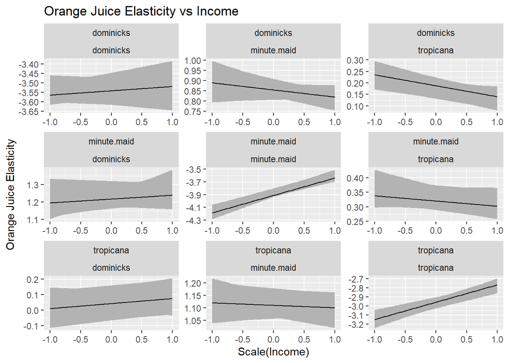

```r
cate_effect_interval_long %>%
  ggplot(aes(Xtest, mid)) +
  geom_ribbon(aes(ymin = down, ymax = up),
              fill = "grey70") +
  geom_line() +
  facet_wrap( ~ product + cross_product, scales = "free") +
  labs(
    x = "Scale(Income)",
    y = "Orange Juice Elasticity",
    title = "Orange Juice Elasticity vs Income"
  )
```